# `RAPToR` - Showcase

Romain Bulteau

mars 2020

In this vignette, you will find a showcase of a few useful ways RAPToR can be used.

# Improving a Differential Gene Expression analysis with correct age

## The data

The dataset used in this example corresponds to a *C. elegans* profiling experiment by Lehrbach et al. (2012), hereafter called `dslehrbach2012` (Accession : [E-MTAB-1333](https://www.ebi.ac.uk/arrayexpress/experiments/E-MTAB-1333/)). Profiling was done using microarray (Affymetrix).

The experimental setup is the following. Two *C. elegans* strains : wild-type (`wt`) and pash-1(mj100) (`mut`) were profiled at 0, 6, 12 and 24 hours past the L4 stage (~ 50 hours post-hatching). These were done in triplicates.

In this scenario, performing a Differential Gene Expression (DGE) analysis to uncover the effect of the strain relies on the inclusion of the effect of development. This is true in any time series context, even more so here because the late larval development of *C. elegans* is known to lead to drastic changes in gene expression within a short time frame.

Code to generate `dslehrbach2012` :

##### Hide

##### Show

**Note : set the `data_folder` variable to an existing path on your system where you want to store the objects.**

```r
data_folder <- "../inst/extdata/"

library("biomaRt") # May need to be installed with bioconductor
library("limma")   # ..
library("affy")    # ..
library("gcrma")   # ..

requireNamespace("wormRef", quietly = T)
requireNamespace("utils", quietly = T)
```

###### `dslehrbach202`

```r
# get probe ids from the arrayexpress
probe_ids <- read.table("https://www.ebi.ac.uk/arrayexpress/files/A-AFFY-60/A-AFFY-60.adf.txt", h=T,
                        comment.char = "", sep = "\t", skip = 17, as.is = T)


# pheno data
p_url <- "https://www.ebi.ac.uk/arrayexpress/files/E-MTAB-1333/E-MTAB-1333.sdrf.txt"
p <- read.table(p_url, h = T, sep = "\t", comment.char = "", as.is = T)

# geno data
g_url <- unique(p$Comment..ArrayExpress.FTP.file.)
g_dir <- paste0(data_folder, "dslehrbach2012_raw/")
g_file <- paste0(g_dir, "raw.zip")

if(!file.exists(g_file)){
  dir.create(g_dir)
  utils::download.file(g_url, destfile = g_file)
}
utils::unzip(g_file, exdir = g_dir)

g <- affy::ReadAffy(filenames = p$Array.Data.File, celfile.path = g_dir, phenoData = p)
g <- affy::expresso(g, bg.correct = F, normalize = F,
                    pmcorrect.method = "pmonly", summary.method = "median")
g <- 2^exprs(g) # expresso log2s the data
colnames(g) <- p$Source.Name

# format ids
g <- RAPToR::format_ids(g, probe_ids, from = 1, to = 7)
g <- RAPToR::format_ids(g, wormRef::Cel_genes, from = 3, to = 1)


# filter relevant fields
p <- p[, c(1,22,24)]
colnames(p) <- c("title", "tpastL4", "strain")
p$strain <- factor(p$strain, levels = c('wild type', 'pash-1(mj100)'), labels = c('wt', 'strain'))
p$rep <- factor(gsub("\\w+_h\\d+\\.(\\d)","\\1", p$title))

dslehrbach2012 <- list(g = g, p = p)
save(dslehrbach2012, file = paste0(data_folder, "dslerhbach2012.RData"), compress = "xz")

# cleanup
file.remove(g_file)
unlink(g_dir, recursive = T)

rm(g, g_url, g_dir, g_file, p, p_url, probe_ids)
```

## Normalization

```r
dslehrbach2012$g <- limma::normalizeBetweenArrays(dslehrbach2012$g, method = "quantile")
dslehrbach2012$g <- log(dslehrbach2012$g + 1)
```

## Staging the samples

The samples’ (chronological) ages range from after L4 to 24h past L4. The `Cel_YA_2` reference from `wormRef` covers this range, so we’ll select it to stage the samples.

```r
r_ya <- prepare_refdata("Cel_YA_2", datapkg = "wormRef", n.inter = 200)

ae_dslb <- ae(dslehrbach2012$g, r_ya$interpGE, r_ya$time.series)
```

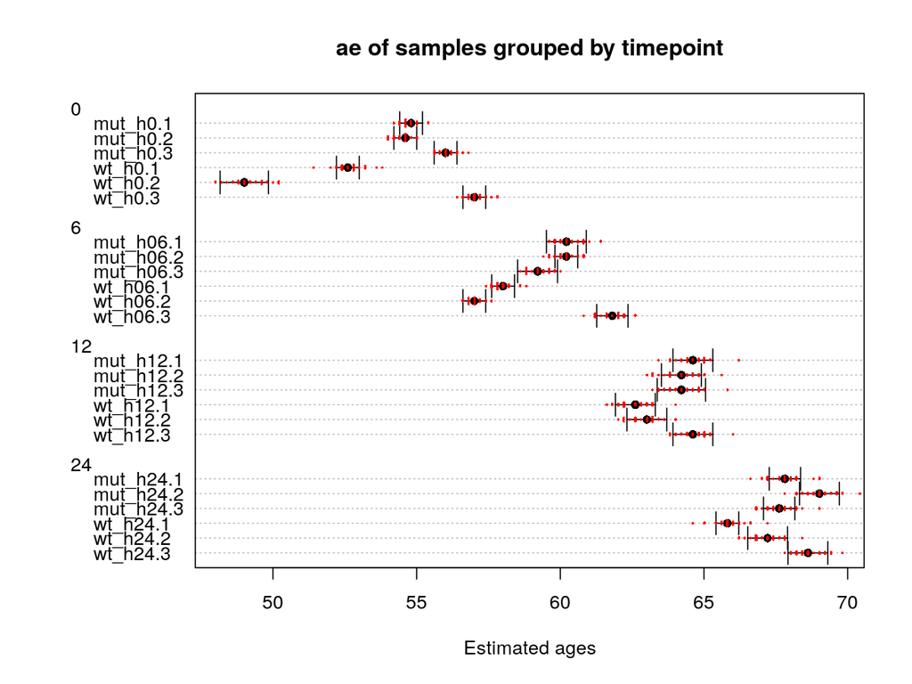

We can see quite a bit of variation in the sample timings, especially at the 0 and 6 hour timepoints. Another interesting effect can be seen if we group the samples by replicate.

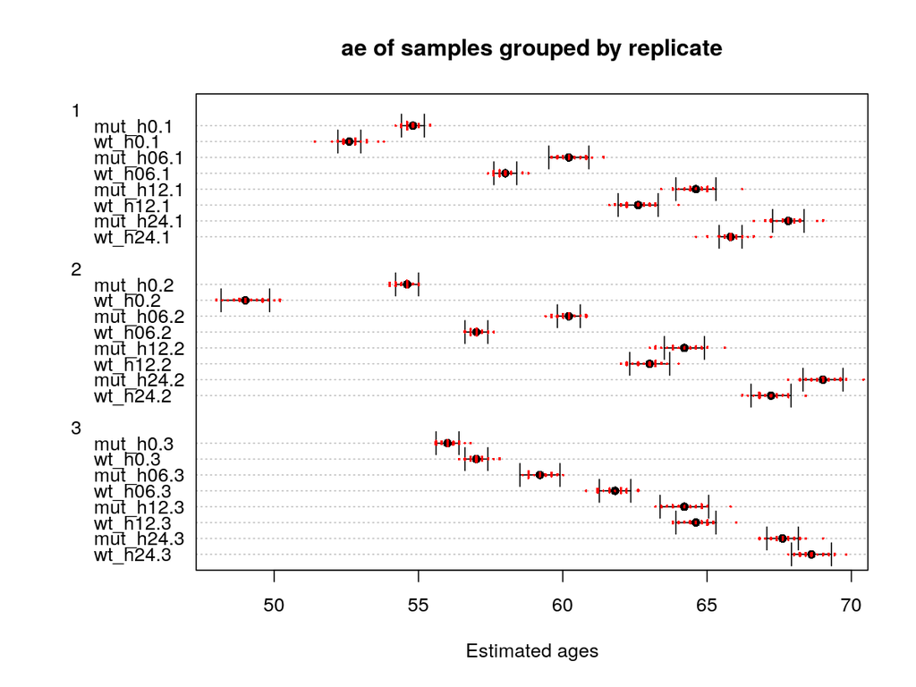

Notice how, in the first two replicates, the `mut` samples are consistantly older than the `wt` ones, which is the opposite way around for the 3rd replicate. We can maybe speculate about a potential effect of their sampling order.

## Correlation is stronger with development than strain

```r
cc <- cor(dslehrbach2012$g, dslehrbach2012$g, method = "spearman")
```

Let’s look at the correlation between the samples and compare it to their estimated age difference. In the plot below, we chose the `wt_h06.3` sample and plotted the correlation and age difference of all samples with it.

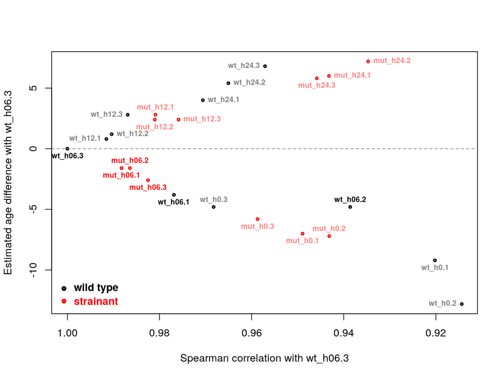

Notice how the strain does not really impact correlation, compared to developmental differences.

## Differential Gene Expression analysis

Let’s perform a simple DGE analysis using limma, with the following model :

$$X \sim strain \times \texttt{ns(age, df = 2)}$$

We’ll compare the number of genes differentially expressed due to development or strains, which translates to comparing the following nested models (2 vs. 1 for development, 3 vs. 1 for strain).

$$\begin{align}
Y & = \beta_0 +
\beta_1 I_{strain} +
(\alpha_1 age_{sp1} + \alpha_2 age_{sp2}) +
(\gamma_1 I_{strain} age_{sp1} + \gamma_2 I_{strain} age_{sp2})\\
Y & = \beta_0 + \beta_1 I_{strain}\\
Y & = \beta_0 + (\alpha_1 age_{sp1} + \alpha_2 age_{sp2})
\end{align}$$

Note that we’re not interested in whether genes are up or down-regulated, but only in the detection of an effect.

DGE code :

##### Hide

##### Show

```r
pred_lmFit <- function(Fit){
  tcrossprod(Fit$coefficients, Fit$design)
}

GoF <- function(Fit, X){
  pred <- pred_lmFit(Fit)
  res <- (X - pred)
  ss <- apply(X, 1, function(ro) sum((ro - mean(ro))^2))
  Rsq <- sapply(seq_len(nrow(X)), function(i){
    1 - sum(res[i,]^2)/ss[i]
  })
  return(Rsq)
}
```

```r
DGE <- function(X, strain, age, df = 2, name = NULL, return.model = FALSE){
  require(splines)
  if(! length(strain) == ncol(X) | ! length(age) == ncol(X))
    stop("strain and age must be of length ncol(X).")

  # make pdat df
  pdat <- data.frame(strain = factor(strain), age = as.numeric(age), row.names = colnames(X))

  # build design matrix
  d <- model.matrix(~ 0 + strain * ns(age, df = df), data = pdat)

  # fix colnames
  colnames(d)[3:(2+2*df)] <- paste0(c(rep("a", df), rep("strainmut.a", df)), 1:df)

  # build contrast matrices for mut and age tests
  if(df == 2){
    cm.mut <- makeContrasts(mut = strainwt - strainmut,
                            mut.i1 = strainmut.a1,
                            mut.i2 = strainmut.a2,
                            levels = d)
    cm.age <- makeContrasts(a1, a2,
                            a.i1 = strainmut.a1,
                            a.i2 = strainmut.a2,
                            levels = d)
  }

  if(df == 3){
    cm.mut <- makeContrasts(mut = strainwt - strainmut,
                            mut.i1 = strainmut.a1,
                            mut.i2 = strainmut.a2,
                            mut.i3 = strainmut.a3,
                            levels = d)
    cm.age <- makeContrasts(a1, a2, a3,
                            a.i1 = strainmut.a1,
                            a.i2 = strainmut.a2,
                            a.i3 = strainmut.a3,
                            levels = d)
  }

  # fit model
  m.0 <- lmFit(object = X, design = d)
  # get GoF
  gof <- GoF(Fit = m.0, X = X)

  # find DE genes for mut
  m.m <- contrasts.fit(m.0, contrasts = cm.mut)
  m.m <- eBayes(m.m)

  # find DE genes for age
  m.a <- contrasts.fit(m.0, contrasts = cm.age)
  m.a <- eBayes(m.a)

  Tmut <- topTable(m.m, adjust.method = "BH", number = Inf, sort.by = "none")[, c("F", "P.Value", "adj.P.Val")]
  Tage <- topTable(m.a, adjust.method = "BH", number = Inf, sort.by = "none")[, c("F", "P.Value", "adj.P.Val")]

  res <- list(gof  = gof,
              tmut = Tmut,
              tage = Tage,
              name = name)
  if(return.model)
    res$model = m.0

  rm(m.0, m.m, m.a, Tmut, Tage, d, X, pdat, gof)
  gc(verbose = F)
  return(res)
}
```

```r
get_ssq <- function(dsgn, X){
  # Get the SSQ explained by the model terms (eg, R anova results)
  ps <- lapply(list(1:2,1:4,1:6), function(s){
    m <- limma::lmFit(X, design = dsgn[, s])
    return(tcrossprod(m$coefficients, m$design))
  })

  ssq <- function(x) sum((x - sum(x)/length(x))^2)

  vs <- lapply(ps, function(p) apply(p, 1, ssq))
  vs <- do.call(cbind, vs)

  vex <- data.frame(strain=vs[,1], age=vs[,2]-vs[,1], age.strain = vs[,3]-vs[,2],
                    ssqExp = vs[,3], ssqTot = apply(X, 1, ssq))
  vex$ssqRes <- vex$ssqTot - vex$ssqExp
  return(vex)
}
```

We want to perform *the same DGE analysis* using the chronological age, and our estimates, to see if there is an improvement in detecting strain and age effect.

```r
# format gdata
X <- log2(exp(dslehrbach2012$g))

dge.ca <- DGE(X = X, strain = dslehrbach2012$p$strain, age = dslehrbach2012$p$tpastL4, name = "dge.ca", return.model = T)
dge.ae <- DGE(X = X, strain = dslehrbach2012$p$strain, age = ae_dslb$age.estimates[,1], name = "dge.ae", return.model = T)
```

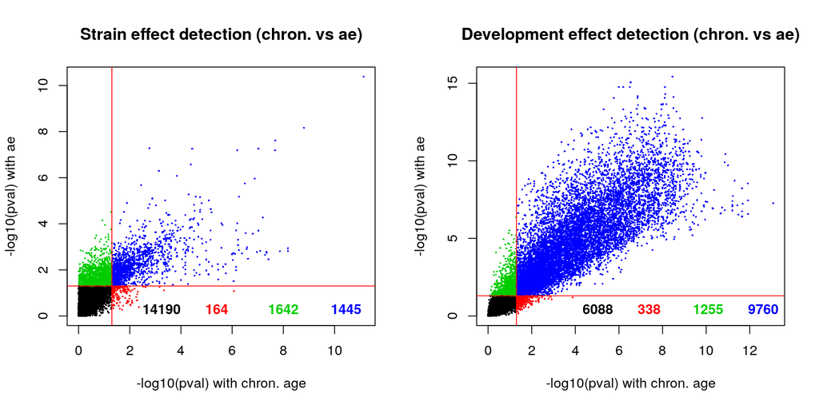

```r
mut_dif.ca <- sum(dge.ca$tmut$adj.P.Val < 0.05)
mut_dif.ae <- sum(dge.ae$tmut$adj.P.Val < 0.05)

age_dif.ca <- sum(dge.ca$tage$adj.P.Val < 0.05)
age_dif.ae <- sum(dge.ae$tage$adj.P.Val < 0.05)

100 * (mut_dif.ae - mut_dif.ca) / (mut_dif.ca) # mut pct increase
```

```
#> [1] 91.8583
```

```r
100 * (age_dif.ae - age_dif.ca) / (age_dif.ca) # age pct increase
```

```
#> [1] 9.081006
```

We detect nearly *twice* as many DE genes for strain using our estimates compared to using the chronological age, and around $10 \%$ more genes with development. This shows how crucial it can be to take developmental dynamics into account correctly in DGE analyses.

We can also see this increase in the model’s fit itself, by looking at the Sum of Squares fraction attributed to model terms (a variance decomposition of sorts).

```r
ssq.ca <- get_ssq(dge.ca$model$design, X = dslehrbach2012$g)
ssq.ae <- get_ssq(dge.ae$model$design, X = dslehrbach2012$g)

# scale to ssqTot for fraction of ssq
ssq.ca <- as.data.frame(apply(ssq.ca, 2, `/`, ssq.ca$ssqTot))
ssq.ae <- as.data.frame(apply(ssq.ae, 2, `/`, ssq.ae$ssqTot))
```

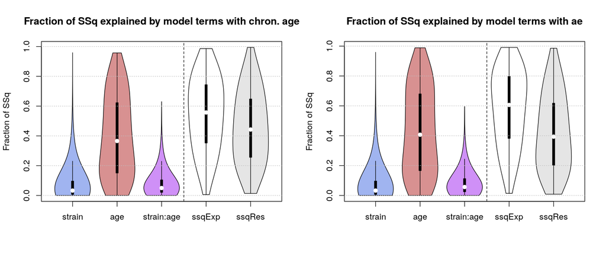

```r
round(colSums(ssq.ca) / nrow(X), 3)
```

```
#>    strain        age age.strain     ssqExp     ssqTot     ssqRes
#>     0.072      0.395      0.075      0.542      1.000      0.458
```

```r
round(colSums(ssq.ae) / nrow(X), 3)
```

```
#>    strain        age age.strain     ssqExp     ssqTot     ssqRes
#>     0.072      0.427      0.080      0.579      1.000      0.421
```

## Compare model fit between chronological age, estimated age, and random noise on chronological age

If the asynchronicity observed with age estimates is erroneous, then using random noise around the chronological values should yield similar results to using our estimates in the model. To test this, we can simulate age sets with random noise of similar distribution to the age differences observed between chronological and estimated age.

To compare the results, we use the model’s Goodness of Fit (GoF) per gene. The GoF computed is an $R^2 = 1 - \frac{SS_{res}}{SS_{tot}}$.

```r
age_diffs <- (dslehrbach2012$p$tpastL4 + 50) - ae_dslb$age.estimates[,1]
# Note : + 50 to shift tpastL4 to age, avoiding generation of negative tpastl4 values,
#        this has no impact on the DGE (it just shifts the age window).

# estimate density function of age_diffs
d_ad <- density(age_diffs)

# generate age sets of with random age_diffs-like noise
set.seed(10)

n <- 100
rd_ages <- lapply(seq_len(n), function(i){
  (dslehrbach2012$p$tpastL4 + 50) + sample(x = d_ad$x, size = nrow(dslehrbach2012$p), prob = d_ad$y, replace = T)
})
```

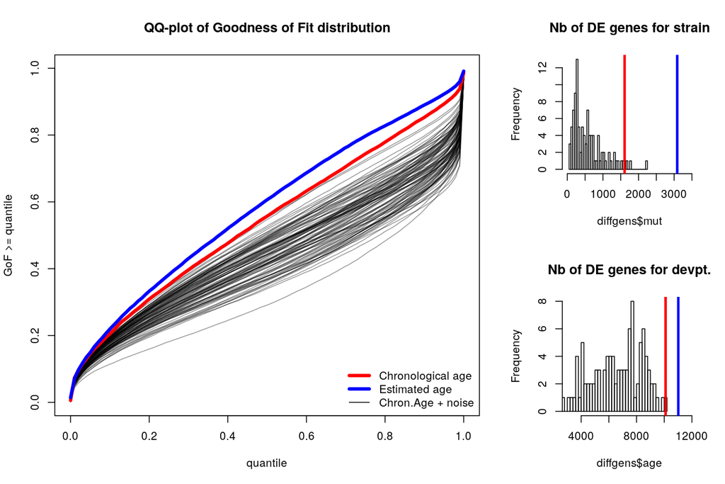

```r
# do DGE on all age sets
cl <- makeCluster(3, "FORK")

rd_dges <- parLapply(cl, seq_len(n), function(i){
  cat("\r", i,"/",n)
  DGE(X, dslehrbach2012$p$strain, rd_ages[[i]], name = paste0("rd.",i))
})

stopCluster(cl)
gc()
```

In the plots above, we can see that using the estimated age leads to better model fits and an increased number of differentially expressed genes.

We can also look at the GoF distributions ordered by chronological age quantiles. The gene GoF are binned along the quantile scale, and shown as boxplots instead of scatterplot for a clearer view.

The Chronological age GoF QQ line is the same as for the previous plot (since the GoF values are ordered according to it).

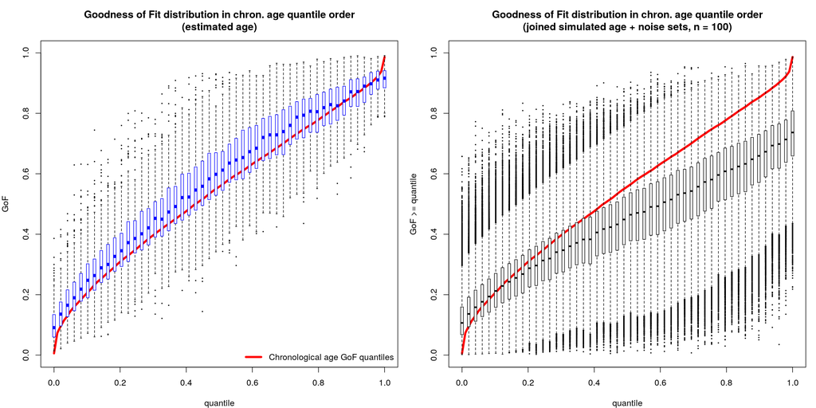

We can see that using our estimates overall outperforms the random noise sets *and* the chronological age.

# Staging samples cross-species

Let’s stage samples cross-species using orthologs genes.

### The data

We’ll be woring with 3 datasets here.

- 2 embryonic timecourse datasets published by Levin et al. (2016), for *D. melanogaster* and *C. elegans*, hereafter called `dslevin2016dmel` and `dslevin2016cel` respectively. (Accessions : GSE60471 and GSE60755)
- A Drosophila embryonic development time series, part of the modENCODE project and published by Graveley et al. (2011), hereafter called `dsgraveley2011`. (Data downloaded from [fruitfly.org](https://fruitfly.org/sequence/download.html))

Furthermore, we’ll use a set of orthologs between *D. melanogaster* and *C. elegans*, from the supplementary data of Li et al. (2014). This list will be stored in the `glist` object.

Since it can get a little confusing between the plots below, the *D.melanogaster* **samples will always be in red** and the *C. elegans* **samples will always be in blue**

### Workflow

First, we know the drosophila time series (`dslevin2016dmel`) has imprecise chronological ages, so we’ll build a reference with the `dsgraveley2011` data (as in the second example of the reference-building vignette) and stage the drosophila series on it to get accurate developmental timings.

#### *D. melanogaster* on *C. elegans*

We’ll filter the data to keep only the orthologs between *D. melanogaster* and *C. elegans* (and convert FBgn IDs to WBGene IDs).

Then, we’ll build a reference with the `dslevin2016cel` data (and stage its samples on it).

Finally, stage the Drosophila samples on it.

#### *C. elegans* on *D. melanogaster*

We’ll filter the data to only the orthologs between *D. melanogaster* and *C. elegans* (and convert WBGene IDs to FBgn IDs).

Then we’ll use the reference built with the `dsgraveley2011` to stage the `dslevin2016cel` samples on it.

Code to generate `glist`, `dslevin2016dmel`, `dslevin2016cel` and `dsgraveley2011` :

##### Hide

##### Show

**Note : set the `data_folder` variable to an existing path on your system where you want to store the objects.**

```r
data_folder <- "../inst/extdata/"

requireNamespace("wormRef", quietly = T)
requireNamespace("utils", quietly = T)
requireNamespace("GEOquery", quietly = T) # May need to be installed with bioconductor
requireNamespace("Biobase", quietly = T)
```

```r
raw2rpkm <- function(X, gene.length, id.col = 1, l.col='length'){
  # Compute RPKM from raw counts
  if(!all(rownames(X)%in%gene.length[, id.col])){
    stop("Some genes are missing length info !")
  }
  res <- sapply(colnames(X), function(samp){
    pm <- sum(X[,samp])/1e6
    rpkm <- (X[,samp]/pm)/(gene.length[match(rownames(X), gene.length[, id.col]), l.col]/1000)
  })
  rownames(res) <- rownames(X)
  return(res)
}
```

```r
requireNamespace("biomaRt", quietly = TRUE)

mart <- biomaRt::useMart("ensembl", dataset = "dmelanogaster_gene_ensembl")
dmel_genes <- biomaRt::getBM(attributes = c("ensembl_gene_id",
                                            "ensembl_transcript_id",
                                            "external_gene_name",
                                            "transcript_length"),
                              mart = mart)
colnames(dmel_genes)[1:3] <- c("fb_id", "transcript_id", "gene_name")
rm(mart)
```

`glist`

Get list of ortholog genes between *C. elegans* and *D. melanogaster* from Li et al. (2014) supplementary table 1.

```r
tmp_file <- paste0(data_folder, "dmel_cel_orth.zip")
tmp_fold <- paste0(data_folder, "dmel_cel_orth/")
f_url <- "https://genome.cshlp.org/content/suppl/2014/05/15/gr.170100.113.DC1/Supplemental_Files.zip"

utils::download.file(url = f_url, destfile = tmp_file)
utils::unzip(tmp_file, exdir = tmp_fold)

glist <- read.table(paste0(tmp_fold, "Supplementary\ files/TableS1\ fly-worm\ ortholog\ pairs.txt"),
                    skip = 1, h=T, sep = "\t", as.is = T, quote = "\"")
colnames(glist) <- c("fb_id", "dmel_name", "cel_id", "cel_name")
glist$wb_id <- wormRef::Cel_genes[match(glist$cel_id, wormRef::Cel_genes$sequence_name), "wb_id"]

save(glist, file = paste0(data_folder, "sc2_glist.RData"), compress = "xz")

file.remove(tmp_file)
unlink(tmp_fold, recursive = T)
rm(tmp_file, tmp_fold, f_url)
```

`dslevin2016dmel`

```r
geo_dslevin2016dmel <- "GSE60471"

g_url_dslevin2016dmel <- GEOquery::getGEOSuppFiles(geo_dslevin2016dmel, makeDirectory = FALSE, fetch_files = FALSE)
g_file_dslevin2016dmel <- paste0(data_folder, "dslevin2016dmel.txt.gz")
utils::download.file(url = as.character(g_url_dslevin2016dmel$url[3]), destfile = g_file_dslevin2016dmel)

X_dslevin2016dmel <- read.table(gzfile(g_file_dslevin2016dmel), h = T, sep = '\t', as.is = T, row.names = 1, comment.char = "")

# filter poor quality samples
cm_dslevin2016dmel <- RAPToR::cor.gene_expr(X_dslevin2016dmel, X_dslevin2016dmel)
f_dslevin2016dmel <- which(0.6 > apply(cm_dslevin2016dmel, 1, quantile, probs = .99))
X_dslevin2016dmel <- X_dslevin2016dmel[, -f_dslevin2016dmel]

# convert to rpkm & FBgn
X_dslevin2016dmel <- RAPToR::format_ids(X_dslevin2016dmel, dmel_genes, from = "fb_id", to = "fb_id")
X_dslevin2016dmel <- raw2rpkm(X = X_dslevin2016dmel, gene.length = dmel_genes, id.col = "fb_id", l.col = "transcript_length")


# pheno data
P_dslevin2016dmel <- Biobase::pData(GEOquery::getGEO(geo_dslevin2016dmel, getGPL = F)[[1]])

# filter relevant fields/samples
P_dslevin2016dmel <- P_dslevin2016dmel[, c("title", "geo_accession", "time (minutes cellularization stage):ch1")]
colnames(P_dslevin2016dmel)[3] <- "time"
P_dslevin2016dmel$title <- as.character(P_dslevin2016dmel$title)

P_dslevin2016dmel <- P_dslevin2016dmel[P_dslevin2016dmel$title %in% colnames(X_dslevin2016dmel),]
X_dslevin2016dmel <- X_dslevin2016dmel[, P_dslevin2016dmel$title]

# formatting
P_dslevin2016dmel$title <- gsub('Metazome_Drosophila_timecourse_', '', P_dslevin2016dmel$title)
colnames(X_dslevin2016dmel) <- P_dslevin2016dmel$title

P_dslevin2016dmel$age <- as.numeric(P_dslevin2016dmel$time) / 60

dslevin2016dmel <- list(g = X_dslevin2016dmel, p = P_dslevin2016dmel)
save(dslevin2016dmel, file = paste0(data_folder, "dslevin2016dmel.RData"), compress = "xz")

# cleanup
file.remove(g_file_dslevin2016dmel)
rm(geo_dslevin2016dmel, g_url_dslevin2016dmel, g_file_dslevin2016dmel,
   f_dslevin2016dmel, cm_dslevin2016dmel, X_dslevin2016dmel, P_dslevin2016dmel)
```

`dslevin2016cel`

```r
geo_dslevin2016cel <- "GSE60755"

g_url_dslevin2016cel <- GEOquery::getGEOSuppFiles(geo_dslevin2016cel, makeDirectory = FALSE, fetch_files = FALSE)
g_file_dslevin2016cel <- paste0(data_folder, "dslevin2016cel.txt.gz")
utils::download.file(url = as.character(g_url_dslevin2016cel$url[1]), destfile = g_file_dslevin2016cel)

X_dslevin2016cel <- read.table(gzfile(g_file_dslevin2016cel), h = T, sep = '\t', as.is = T, row.names = 1, comment.char = "")

# filter poor quality samples
cm_dslevin2016cel <- RAPToR::cor.gene_expr(X_dslevin2016cel, X_dslevin2016cel)
f_dslevin2016cel <- which(0.67 > apply(cm_dslevin2016cel, 1, quantile, probs = .99))
X_dslevin2016cel <- X_dslevin2016cel[, -f_dslevin2016cel]

# convert to rpkm & FBgn
X_dslevin2016cel <- RAPToR::format_ids(X_dslevin2016cel, wormRef::Cel_genes, from = "sequence_name", to = "wb_id")
X_dslevin2016cel <- raw2rpkm(X = X_dslevin2016cel, gene.length = wormRef::Cel_genes, id.col = "wb_id", l.col = "transcript_length")


# pheno data
P_dslevin2016cel <- Biobase::pData(GEOquery::getGEO(geo_dslevin2016cel, getGPL = F)[[1]])

# filter relevant fields/samples
P_dslevin2016cel <- P_dslevin2016cel[, c("title", "geo_accession", "time point (minutes after 4-cell):ch1")]
colnames(P_dslevin2016cel)[3] <- "time"
P_dslevin2016cel$title <- as.character(P_dslevin2016cel$title)

P_dslevin2016cel <- P_dslevin2016cel[P_dslevin2016cel$title %in% colnames(X_dslevin2016cel),]

# formatting
P_dslevin2016cel$age <- as.numeric(P_dslevin2016cel$time) / 60
P_dslevin2016cel <- P_dslevin2016cel[order(P_dslevin2016cel$age),]
X_dslevin2016cel <- X_dslevin2016cel[, P_dslevin2016cel$title]

P_dslevin2016cel$title <- gsub('Metazome_CE_timecourse_', '', P_dslevin2016cel$title)
colnames(X_dslevin2016cel) <- P_dslevin2016cel$title

X_dslevin2016cel <- X_dslevin2016cel[,-127] # remove extra outlier
P_dslevin2016cel <- P_dslevin2016cel[-127,]


dslevin2016cel <- list(g = X_dslevin2016cel, p = P_dslevin2016cel)
save(dslevin2016cel, file = paste0(data_folder, "dslevin2016cel.RData"), compress = "xz")

# cleanup
file.remove(g_file_dslevin2016cel)
rm(geo_dslevin2016cel, g_url_dslevin2016cel, g_file_dslevin2016cel,
   f_dslevin2016cel, cm_dslevin2016cel, X_dslevin2016cel, P_dslevin2016cel)
```

`dsgraveley2011`

```r
g_url_dsgraveley2011 <- "ftp://ftp.fruitfly.org/pub/download/modencode_expression_scores/Celniker_Drosophila_Annotation_20120616_1428_allsamps_MEAN_gene_expression.csv.gz"
g_file_dsgraveley2011 <- paste0(data_folder, "dsgraveley2011.csv.gz")
utils::download.file(g_url_dsgraveley2011, destfile = g_file_dsgraveley2011)


X_dsgraveley2011 <- read.table(gzfile(g_file_dsgraveley2011), sep = ',', row.names = 1, h = T)

# convert gene ids to FBgn
X_dsgraveley2011 <- RAPToR::format_ids(X_dsgraveley2011, dmel_genes, from = "gene_name", to = "fb_id")

# select embryo time series samples
X_dsgraveley2011 <- X_dsgraveley2011[,1:12]

P_dsgraveley2011 <- data.frame(sname = colnames(X_dsgraveley2011),
                    age = as.numeric(gsub("em(\\d+)\\.\\d+hr", "\\1", colnames(X_dsgraveley2011))),
                    stringsAsFactors = FALSE)

dsgraveley2011 <- list(g = X_dsgraveley2011, p = P_dsgraveley2011)

save(dsgraveley2011, file = paste0(data_folder, "dsgraveley2011.RData"), compress = "xz")

# cleanup
file.remove(g_file_dsgraveley2011)
rm(g_url_dsgraveley2011, g_file_dsgraveley2011, X_dsgraveley2011, P_dsgraveley2011)
```

### Normalization

```r
dsgraveley2011$g <- limma::normalizeBetweenArrays(dsgraveley2011$g, method = "quantile")
dsgraveley2011$g <- log(dsgraveley2011$g + 1)

dslevin2016dmel$g <- limma::normalizeBetweenArrays(dslevin2016dmel$g, method = "quantile")
dslevin2016dmel$g <- log(dslevin2016dmel$g + 1)

dslevin2016cel$g <- limma::normalizeBetweenArrays(dslevin2016cel$g, method = "quantile")
dslevin2016cel$g <- log(dslevin2016cel$g + 1)
```

```r
dslevin2016cel$g_cel <- format_ids(dslevin2016cel$g, glist, from = "wb_id", to = "wb_id")
dslevin2016dmel$g_cel <- format_ids(dslevin2016dmel$g, glist, from = "fb_id", to = "wb_id")
```

### Staging the Drosophila embryo time course

We know from previous use of the `dslevin2016dmel` dataset that its samples have rather imprecise chronological-developmental synchronicity (see the refbuilding vignette’s 2nd example for more information). We’ll first estimate the age of the samples and use that as a basis for the comparison when staging on *C. elegans data*.

```r
m_grav <- ge_im(X = dsgraveley2011$g, p = dsgraveley2011$p, formula = "X ~ s(age, bs = 'cr')", nc = 4)

n.inter <- 200
newdat <- data.frame(
  age = seq(min(dsgraveley2011$p$age), max(dsgraveley2011$p$age), l = n.inter)
)
r_grav <- list(interpGE = predict(m_grav, newdata = newdat), time.series = newdat$age)
ae_dmel <- ae(dslevin2016dmel$g, r_grav$interpGE, r_grav$time.series)

dslevin2016dmel$p$ae <- ae_dmel$age.estimates[,1]
```

### *D. melanogaster* on *C. elegans*

#### Build a C. elegans embryo reference

As we have components that are rather noisy with this data, we’ll only use 5 components to build the reference.

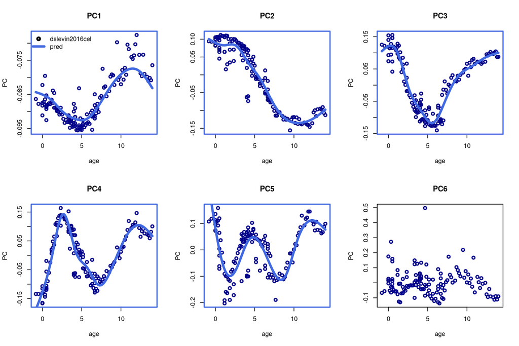

```r
pca_cel <- stats::prcomp(dslevin2016cel$g_cel, rank = 10)
nc <- 5

m_cel <- ge_im(X = dslevin2016cel$g_cel, p = dslevin2016cel$p, formula = "X ~ s(age, bs = 'cr')", nc = nc)

n.inter <- 200 # nb of new timepoints
newdat <- data.frame(
  age = seq(min(dslevin2016cel$p$age), max(dslevin2016cel$p$age), l = n.inter)
)

pred_cel_comp <- predict(m_cel, newdata = newdat, as.c = T) # for plotting

r_cel <- list(interpGE = predict(m_cel, newdata = newdat), time.series = newdat$age)
```

Check the reference by staging its samples on it :

```r
ae_cel_on_cel <- ae(dslevin2016cel$g_cel, r_cel$interpGE, r_cel$time.series)
```

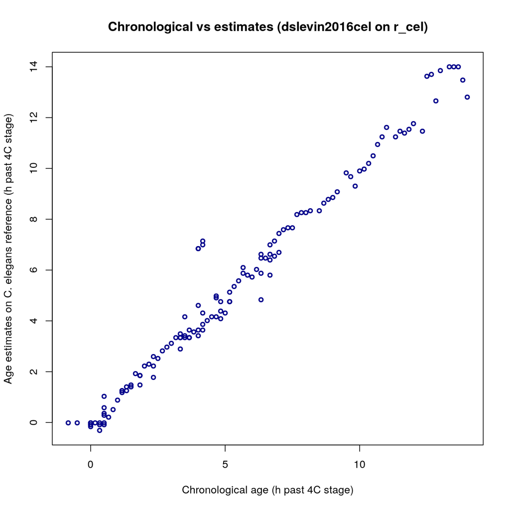

#### Stage *D. melanogaster* embryos on *C. elegans* reference

```r
ae_dmel_on_cel <- ae(dslevin2016dmel$g_cel, r_cel$interpGE, r_cel$time.series)
```

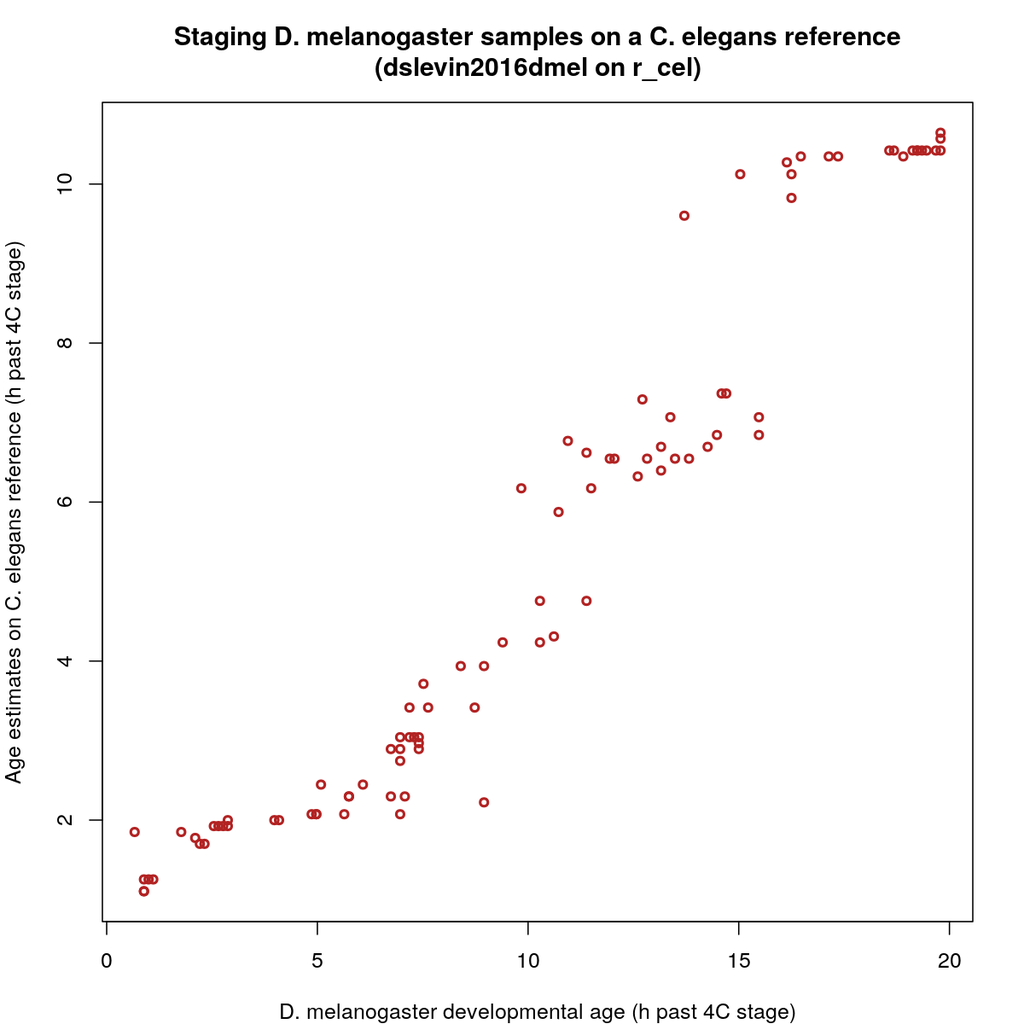

### *C. elegans* on *D. melanogaster*

We have already built a *D. melanogaster* with `dsgraveley2011`, which we can use directly here.

```r
dslevin2016cel$g_dmel <- format_ids(dslevin2016cel$g, glist, from = "wb_id", to = "fb_id")
ae_cel_on_dmel <- ae(dslevin2016cel$g_dmel, r_grav$interpGE, r_grav$time.series)
```

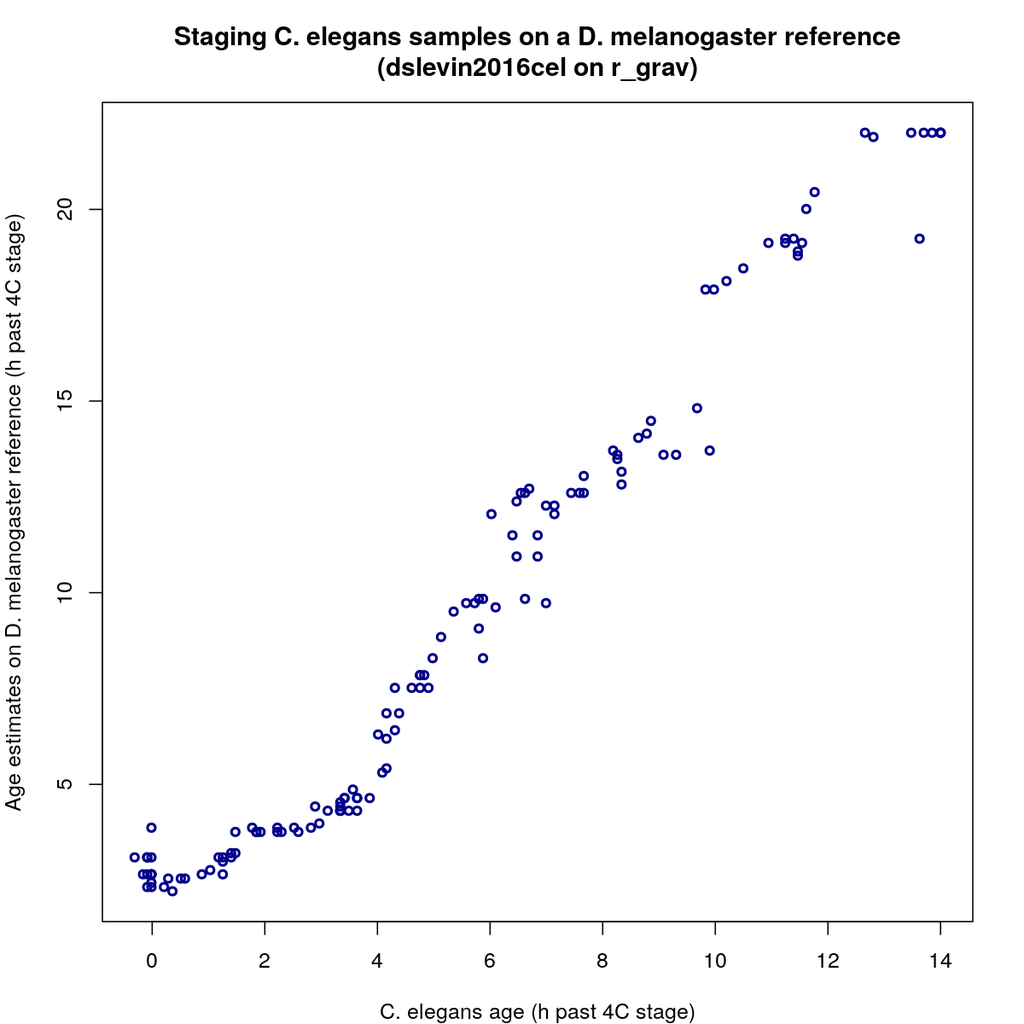

# Capturing tissue-specific development

Let’s perform tissue-specific staging.

### The data

We’ll be working with a dataset published by Rockman, Skrovanek, and Kruglyak (2010).

This dataset correpsonds to microarray profiling of 208 recombinant inbred lines of *C. elegans* N2 and Hawaii (CB4856) strains. These 208 samples were described as *“developmentally synchronized”* in the original paper. However, it was later demonstrated that a very significant developmental spread of the samples existed, spanning around 20 hours of $20^\circ C$ late larval development existed (Francesconi and Lehner (2014)).

This essentially makes this dataset a very high-resolution timecourse of late-larval development.

### Workflow

In *C. elegans*, there is a known heterochrony of soma and germline development.  
Using RAPToR, we can capture tissue-specific age by restricting the geneset used for staging to the tissue of interest.

#### Gene subsets

We define a `germline` geneset of 2554 genes from joining the `germline_intrinsic`, `germline_oogenesis_enriched` and `germline_sperm_enriched` categories defined in Perez et al. (2017).

We define a `soma` geneset of 2718 genes from the `osc` gene category defined in Hendriks et al. (2014).

#### Staging

A first staging is done with all available genes : this corresponds to the “**Global age**”.

Then, tissue-specific staging is simply done by limiting the genes to the previously mentioned sets. The estimates from the soma and germline gene subsets are called “**Soma age**” and “**Germline age**” respectively.

#### Validation

We can look at PCA or ICA components against the different ages to evaluate the results. We can *e.g.* expect components corresponding to molting (oscillatory) processes to be “cleaner” with the soma estimates, consequently introducing noise on the germline components and vice-versa.

Code to generate `dsrockman2010` and `gsubset`.

##### Hide

##### Show

**Note : set the `data_folder` variable to an existing path on your system where you want to store the objects.**

```r
data_folder <- "../inst/extdata/"

requireNamespace("wormRef", quietly = T)
requireNamespace("utils", quietly = T)
requireNamespace("GEOquery", quietly = T) # May need to be installed with bioconductor
requireNamespace("Biobase", quietly = T)
requireNamespace("limma", quietly = T)
```

```r
geo_dsrockman2010 <- "GSE23857"
geo_dsrockman2010 <- GEOquery::getGEO(geo_dsrockman2010, GSEMatrix = F)

# get pdata
P_dsrockman2010 <- do.call(rbind, lapply(GEOquery::GSMList(geo_dsrockman2010), function(go){
  unlist(GEOquery::Meta(go)[
    c("geo_accession", "characteristics_ch1", "characteristics_ch2",
      "label_ch1", "label_ch2")]
  )
}))

P_dsrockman2010 <- as.data.frame(P_dsrockman2010, stringsAsFactors = F)

# get RG data from microarray
RG_dsrockman2010 <- list(
  R = do.call(cbind, lapply(GEOquery::GSMList(geo_dsrockman2010), function(go){
      GEOquery::Table(go)[, "R_MEAN_SIGNAL"]
    })),
  G = do.call(cbind, lapply(GEOquery::GSMList(geo_dsrockman2010), function(go){
    GEOquery::Table(go)[, "G_MEAN_SIGNAL"]
  }))
)

# normalize within channels
RG_dsrockman2010 <- limma::normalizeWithinArrays(RG_dsrockman2010, method = "loess")
RG_dsrockman2010 <- limma::RG.MA(RG_dsrockman2010) # convert back from MA to RG

# get only the RIALs (not the mixed stage controls)
X_dsrockman2010 <- RG_dsrockman2010$R
X_dsrockman2010[, P_dsrockman2010$label_ch1 == "Cy5"] <- RG_dsrockman2010$G[, P_dsrockman2010$label_ch1 == "Cy5"]

# format probe/gene ids
gpl <- GEOquery::getGEO(GEOquery::Meta(GEOquery::GSMList(geo_dsrockman2010)[[1]])$platform_id)
gpl <- GEOquery::Table(gpl)
gpl <- gpl[as.character(gpl$ID) %in% as.character(GEOquery::Table(GEOquery::GSMList(geo_dsrockman2010)[[1]])$ID_REF), ]

sel <- gpl$ORF%in%wormRef::Cel_genes$sequence_name
gpl <- gpl[sel,]
X_dsrockman2010 <- X_dsrockman2010[sel,]


# filter bad quality samples
cm_dsrockman2010 <- cor(log1p(X_dsrockman2010), method = 'spearman')
f_dsrockman2010 <- which(0.95 > apply(cm_dsrockman2010, 1, quantile, probs = .95))

X_dsrockman2010 <- X_dsrockman2010[,-f_dsrockman2010]
P_dsrockman2010 <- P_dsrockman2010[-f_dsrockman2010,]

rownames(X_dsrockman2010) <- gpl$ORF
X_dsrockman2010 <- RAPToR::format_ids(X_dsrockman2010, wormRef::Cel_genes,
                                  from = "sequence_name", to = "wb_id")


dsrockman2010 <- list(g = X_dsrockman2010, p = P_dsrockman2010)

save(dsrockman2010, file = paste0(data_folder, "dsrockman2010.RData"), compress = "xz")
rm(geo_dsrockman2010, gpl, sel, RG_dsrockman2010, X_dsrockman2010, P_dsrockman2010,
   cm_dsrockman2010, f_dsrockman2010)
```

```r
library(readxl)
germline_url <- "https://static-content.springer.com/esm/art%3A10.1038%2Fnature25012/MediaObjects/41586_2017_BFnature25012_MOESM3_ESM.xlsx"
germline_file <- paste0(data_folder, "germline_gset.xlsx")
utils::download.file(url = germline_url, destfile = germline_file)

germline_set <- read_xlsx(germline_file, sheet = 3, na = "NA")[,c(1, 44:46)]
germline_set <- cbind(wb_id = germline_set[,1],
                      germline = apply(germline_set[, 2:4], 1, function(r) any(r)))
germline_set$germline[is.na(germline_set$germline)] <- FALSE
germline_set <- germline_set[germline_set$germline,1]

soma_url <- "https://ars.els-cdn.com/content/image/1-s2.0-S1097276513009039-mmc2.xlsx"
soma_file <- paste0(data_folder, "soma_gset.xlsx")
utils::download.file(url = soma_url, destfile = soma_file)

soma_set <- read_xlsx(soma_file, skip = 3, na = "NA")[,c(1, 4)]
soma_set$class <- factor(soma_set$class)

soma_set$soma <- soma_set$class == "osc"
soma_set <- soma_set[soma_set$soma, 1]

gsubset <- list(germline = germline_set, soma = soma_set$`Gene WB ID`)

save(gsubset, file = paste0(data_folder, "sc3_gsubset.RData"), compress = "xz")

file.remove(germline_file)
file.remove(soma_file)
rm(germline_url, germline_file, germline_set, soma_url, soma_file, soma_set)
```

### Normalization

```r
dsrockman2010$g <- limma::normalizeBetweenArrays(dsrockman2010$g, method = "quantile")
dsrockman2010$g <- log(dsrockman2010$g + 1)
```

### Staging the samples (global)

We can use one of the young-adult references for *C. elegans* to stage the samples

```r
r_ya <- prepare_refdata("Cel_YA_1", "wormRef", n.inter = 400)

ae_dsrockman2010 <- ae(dsrockman2010$g, r_ya$interpGE, r_ya$time.series)
```

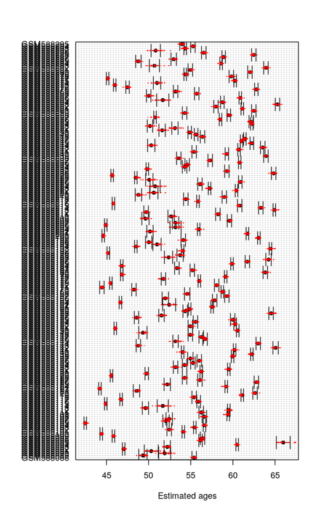

### Dynamics of the dataset

We can use PCA or ICA components to look at the dynamics of the dataset on a global scale.

```r
pca_rock <- stats::prcomp(dsrockman2010$g, rank = 5)
```

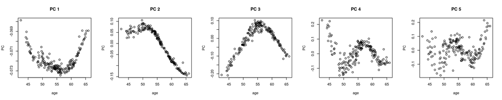

```r
ica_rock <- ica::icafast(dsrockman2010$g, nc = 5)
```

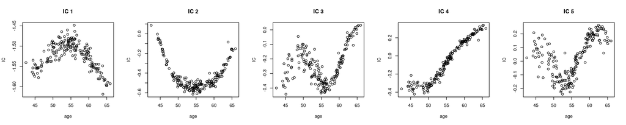

### Staging the samples (soma & germline)

Now, we stage the samples using only germline or soma gene subsets.

```r
ae_soma <- ae(
  dsrockman2010$g[rownames(dsrockman2010$g)%in%gsubset$soma,], # select soma gene subset
  r_ya$interpGE, r_ya$time.series
  )

ae_germline <- ae(
  dsrockman2010$g[rownames(dsrockman2010$g)%in%gsubset$germline,], # select germline gene subset
  r_ya$interpGE, r_ya$time.series
  )
```

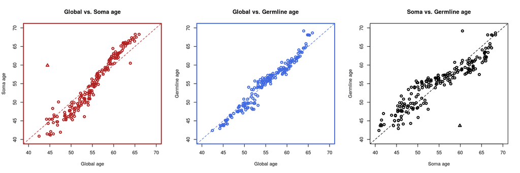

We can notice on the soma estimates that a sample appears quite off from its global or germline age (it’s marked with a $\triangle$). This sort of artefact can happen when using small genesets for estimates, as similar expression profiles can occur at different times (which is especially true for oscillatory profiles).

If we look at the correlation profile of this sample on the 3 estimates, we can see 2 peaks for the soma:

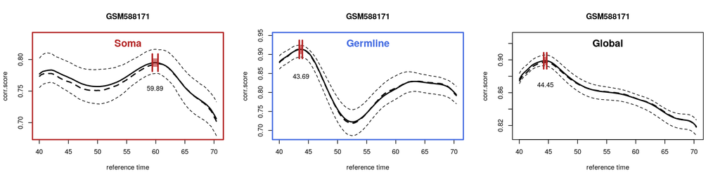

This scenario is a prime example of when it is appropriate to use a prior. We can input the global age as a prior to favor the first peak of the soma correlation profile.

```r
ae_soma_prior <- ae(
  dsrockman2010$g[rownames(dsrockman2010$g)%in%gsubset$soma,], # select soma gene subset
  r_ya$interpGE, r_ya$time.series,
  prior = ae_dsrockman2010$age.estimates[,1], # gaussian prior values (mean)
  prior.params = 10                           # gaussian prior sd
  )
```

This now shifts our estimates to the first peak (note that the correlation profile itself is not changed).

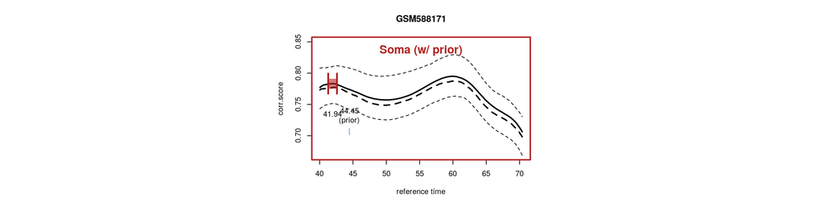

At the same time, all of our other estimates essentially stay the same.

```r
# 80 is the index of the GSM588171 sample
summary(ae_soma$age.estimates[-80, 1] - ae_soma_prior$age.estimates[-80, 1])
```

```
#>     Min.  1st Qu.   Median     Mean  3rd Qu.     Max.
#> -1.06496  0.00000  0.00000 -0.03407  0.00000  1.06496
```

Now, we can look once more at the components of our data using our tissue-specific estimates. We’ll use the prior version of the soma estimates for the plots below.

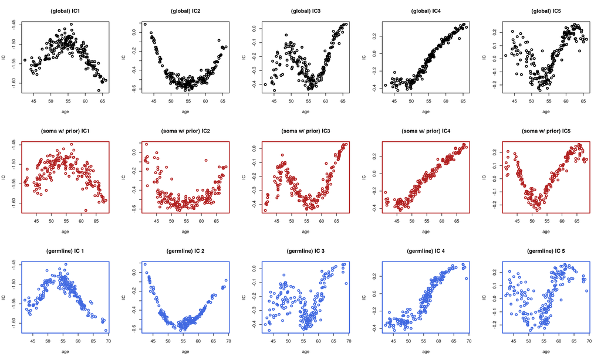

Notice how components IC3 and IC5, oscillatory dynamics, are much cleaner when plotting with the soma age. Also, see that the IC1 and IC2 components appear quite noisy.

With the germline estimates, we get much cleaner dynamics on the first two components, at the cost of clarity on the oscillatory dynamics.

Back to top

# References

Francesconi, Mirko, and Ben Lehner. 2014. “The Effects of Genetic Variation on Gene Expression Dynamics During Development.” *Nature* 505 (7482). Nature Publishing Group: 208.

Graveley, Brenton R, Angela N Brooks, Joseph W Carlson, Michael O Duff, Jane M Landolin, Li Yang, Carlo G Artieri, et al. 2011. “The Developmental Transcriptome of Drosophila Melanogaster.” *Nature* 471 (7339). Nature Publishing Group: 473.

Hendriks, Gert-Jan, Dimos Gaidatzis, Florian Aeschimann, and Helge Großhans. 2014. “Extensive Oscillatory Gene Expression During c. Elegans Larval Development.” *Molecular Cell* 53 (3). Elsevier: 380–92.

Lehrbach, Nicolas J, Cecilia Castro, Kenneth J Murfitt, Cei Abreu-Goodger, Julian L Griffin, and Eric A Miska. 2012. “Post-Developmental microRNA Expression Is Required for Normal Physiology, and Regulates Aging in Parallel to Insulin/Igf-1 Signaling in c. Elegans.” *Rna* 18 (12). Cold Spring Harbor Lab: 2220–35.

Levin, Michal, Leon Anavy, Alison G Cole, Eitan Winter, Natalia Mostov, Sally Khair, Naftalie Senderovich, et al. 2016. “The Mid-Developmental Transition and the Evolution of Animal Body Plans.” *Nature* 531 (7596). Nature Publishing Group: 637.

Li, Jingyi Jessica, Haiyan Huang, Peter J Bickel, and Steven E Brenner. 2014. “Comparison of d. Melanogaster and c. Elegans Developmental Stages, Tissues, and Cells by modENCODE Rna-Seq Data.” *Genome Research* 24 (7). Cold Spring Harbor Lab: 1086–1101.

Perez, Marcos Francisco, Mirko Francesconi, Cristina Hidalgo-Carcedo, and Ben Lehner. 2017. “Maternal Age Generates Phenotypic Variation in Caenorhabditis Elegans.” *Nature* 552 (7683). Nature Publishing Group: 106.

Rockman, Matthew V, Sonja S Skrovanek, and Leonid Kruglyak. 2010. “Selection at Linked Sites Shapes Heritable Phenotypic Variation in c. Elegans.” *Science* 330 (6002). American Association for the Advancement of Science: 372–76.